# [Chapter 5] Exploring the global organ donation trends data

[DSLC stages]: EDA

In this document, we will conduct an EDA of the organ donation data. The general format of this document is that each section involves asking a question of the data and we then produce several exploratory visualizations to answer the question. Interesting findings are evaluated using PCS, and a few are turned into explanatory findings.

Let’s load and clean/pre-process the organ donation data (recall that we developed the cleaning/pre-processing workflow in the file `01_cleaning.qmd`, and saved our cleaning function in the file `functions/prepareOrganData.R`). It is often helpful to keep a copy of the original uncleaned data in your environment.

```r
library(tidyverse)
library(superheat)
library(patchwork)

# load in the function that will allow us to clean the organ data
source("functions/imputeFeature.R")
source("functions/prepareOrganData.R")

# load in the original data
organs_original <- read_csv("../data/global-organ-donation_2018.csv",
                            col_types = list(`Utilized DBD` = col_number(),
                                             `DD Lung Tx` = col_number(),
                                             `Total Utilized DD` = col_number(),
                                             `LD Lung Tx` = col_number()))

# clean and pre-process the data
organs_preprocessed <- prepareOrganData(organs_original,
                                        .impute_method = "average")
```

Next, since many of our explorations will involve looking at the donor *rates*, let’s create a version of the original and imputed donor counts *per million* (we could have included this in the `prepareOrganData()` function, since it can be thought of as a pre-processing featurization step).

```r
# add a donors_per_mil column for each type of imputed donors col
organs_preprocessed <- organs_preprocessed |>
  # note that we use `population_imputed + 1` in the denominator because there
  # are some countries with a reported population of 0.
  mutate(total_deceased_donors_per_mil = total_deceased_donors / (population_imputed + 1) * 1000000,
         total_deceased_donors_imputed_per_mil = total_deceased_donors_imputed / (population_imputed + 1) * 1000000)
```

## 1 High-level summary of the data

The first question we ask is very vague: *what do the variables in the data look like?* Before looking at specific trends, it’s helpful to give a high-level summary of the variables of interest (let’s focus here on just population, the donor count, and the donor rate per million). These summaries aren’t necessarily supposed to tell a story about the trends in the data, but rather are just supposed to give us a sense of what the data itself looks like.

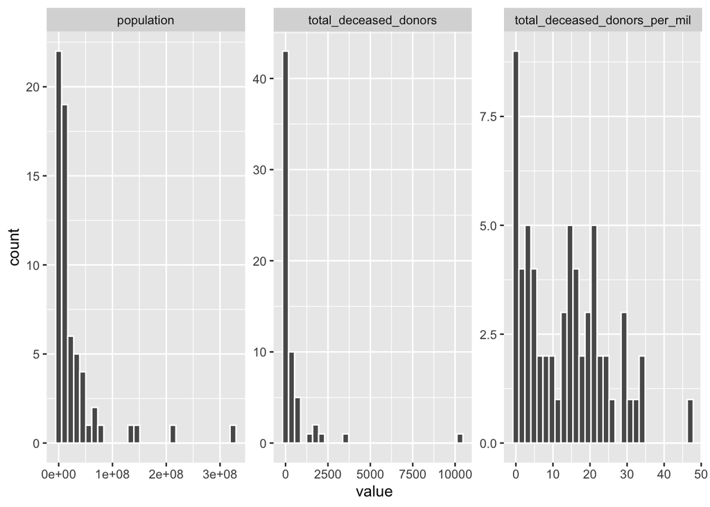

Figure 1: Histograms of the population, donor count, and donor rate (per million) variables.

```r
organs_preprocessed |>
  filter(year == 2017) |>
  select(population, total_deceased_donors, total_deceased_donors_per_mil) |>
  pivot_longer(everything()) |>
  ggplot() +
  geom_histogram(aes(x = value), color = "white") +
  # scales = "free" allows each plot to have its own x-axis
  facet_wrap(~name, scales = "free")
```

The donor count and donor count per million seem to have a concentration around 0.

## 2 Global organ donations are increasing over time

*Are global organ donations are increasing over time*?

Figure 2 shows the increasing trend in (imputed) organ donations across the world over time. The imputed donor counts are based on the “average” imputation method.

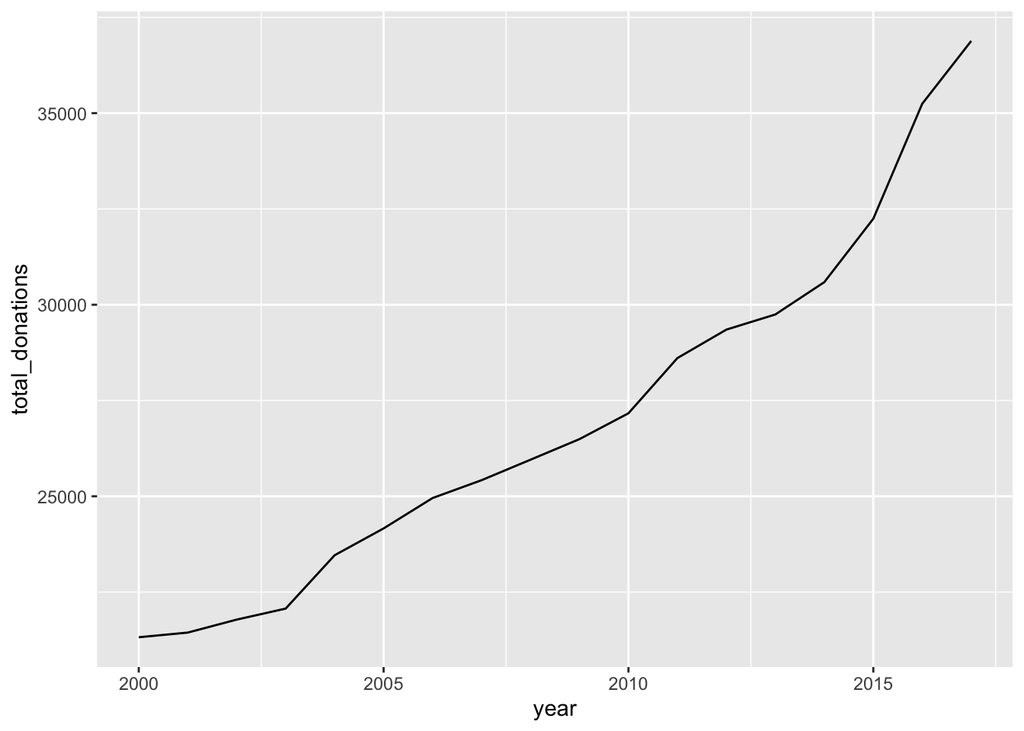

Figure 2: The number of (imputed) organ donations reported each year

```r
organs_preprocessed |>
  # for each year, add up the (imputed) number of organ donations
  group_by(year) |>
  summarise(total_donations = sum(total_deceased_donors_imputed)) |>
  ungroup() |>
  # plot the number of donations using a line plot
  ggplot() +
  geom_line(aes(x = year, y = total_donations))
```

```r
# compute the number of organ donations in 2017
total_2017 <- organs_preprocessed |>
  filter(year == 2017) |>
  summarise(total = sum(total_deceased_donors_imputed)) |>
  pull(total)

# compute the number of organ donations in 2000
total_2000 <- organs_preprocessed |>
  filter(year == 2000) |>
  summarise(total = sum(total_deceased_donors_imputed)) |>
  pull(total)
```

The number of (imputed) reported organ donations in 2017 (3.6885^{4}) is 1.7 times the number of (imputed) reported organ donations in 2000 (2.1321^{4}).

Clearly there has been quite a significant increase in organ donations over time.

### 2.1 PCS evaluation

#### Stability to a cleaning and pre-processing judgment call

Let’s check the stability of the main takeaway from this plot concerning the organ donation trends over time to the imputation judgment call that we made.

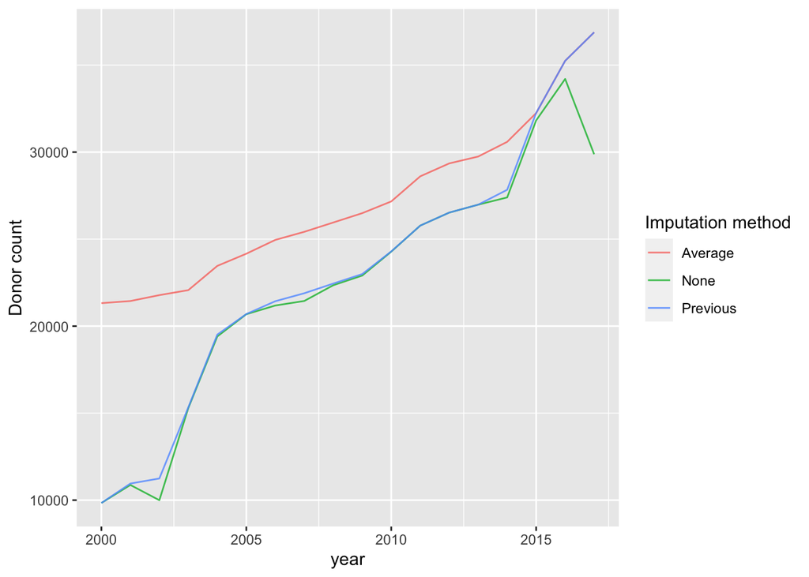

Figure 3: The global organ donation trend according to different imputation techniques

```r
organs_preprocessed |>
  # create the "previous" imputed donor count
  mutate(total_deceased_donors_imputed_previous =
           imputeFeature(organs_preprocessed,
                         .feature = total_deceased_donors,
                         .group = country,
                         .impute_method = "previous")) |>
  group_by(year) |>
  # add up the total donor counts for each year based on the imputation options
  summarise(None = sum(total_deceased_donors, na.rm = T),
            Average = sum(total_deceased_donors_imputed),
            Previous = sum(total_deceased_donors_imputed_previous)) |>
  ungroup() |>
  pivot_longer(c("None", "Average", "Previous"),
               names_to = "Imputation method",
               values_to = "Donor count") |>
  ggplot() +
  geom_line(aes(x = year, y = `Donor count`, color = `Imputation method`), alpha = 0.8)
```

## 3 The US has the *most donors*, but Spain has the *highest donor rate*

The next question we want to ask is *which country had the highest number of organ donations per million people in 2017?*. To answer this question, let’s first print out the donor counts for the 20 countries with the highest donor counts in 2017. In the table below, it is clear that the US has the most organ donations by far, followed by China and Brazil.

```r
countries_top_20_2017 <- organs_preprocessed |>
  # filter to 2017
  filter(year == 2017) |>
  # arrange in descending order of donor count
  arrange(desc(total_deceased_donors_imputed)) |>
  # keep just the top 20 rows
  head(20) |>
  select(country, total_deceased_donors_imputed)
countries_top_20_2017
```

| country | total_deceased_donors_imputed |
| --- | --- |
| United States of America | 10286 |
| China | 4080 |
| Brazil | 3420 |
| Spain | 2183 |
| France | 1933 |
| Italy | 1714 |
| United Kingdom | 1492 |
| Iran (Islamic Republic of) | 870 |
| Canada | 802 |
| Germany | 797 |
| Argentina | 593 |
| Russian Federation | 572 |
| Turkey | 562 |
| Poland | 560 |
| Australia | 510 |
| Mexico | 509 |
| Republic of Korea | 501 |
| Colombia | 437 |
| India | 391 |
| Portugal | 351 |

We can visualize this using a bar chart.

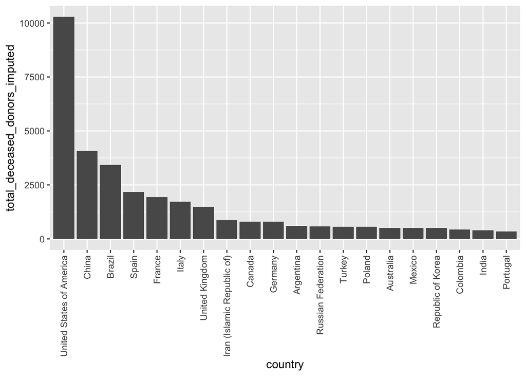

Figure 4: A bar chart showing the number of 2017 organ donations for the 20 countries with the highest number of donations

```r
organs_preprocessed |>
  # filter to the top 20 countries in 2017
  filter(year == 2017, country %in% countries_top_20_2017$country) |>
  # arrange in descending order of donor count
  arrange(desc(total_deceased_donors_imputed)) |>
  # force the countries to appear in the order of donors
  mutate(country = fct_inorder(country)) |>
  # create a bar plot
  ggplot() +
  geom_col(aes(x = country, y = total_deceased_donors_imputed)) +
  theme(axis.text.x = element_text(angle = 90, vjust = 0.5, hjust = 1))
```

Since the populations of each of these countries are quite different, these counts are not actually really comparing apples-to-apples. Let’s instead look at a comparison of the donor counts *per million* for each country.

```r
countries_top_20_2017_per_mil <- organs_preprocessed |>
  # filter to 2017
  filter(year == 2017) |>
  # arrange in descending order of donor count
  arrange(desc(total_deceased_donors_imputed_per_mil)) |>
  # keep just the top 20 rows
  head(20) |>
  select(country, total_deceased_donors_imputed_per_mil)
countries_top_20_2017_per_mil
```

| country | total_deceased_donors_imputed_per_mil |
| --- | --- |
| Spain | 47.04741 |
| Portugal | 34.07767 |
| Croatia | 33.33333 |
| United States of America | 31.69800 |
| Belgium | 30.52631 |
| Malta | 29.99993 |
| France | 29.73846 |
| Italy | 28.85522 |
| Czech Republic | 25.37736 |
| Austria | 24.48276 |
| Belarus | 23.57894 |
| United Kingdom | 22.53776 |
| Canada | 21.91257 |
| Norway | 21.88679 |
| Finland | 21.45454 |
| Australia | 20.81633 |
| Ireland | 20.62500 |
| Slovenia | 20.47618 |
| Iceland | 19.99993 |
| Sweden | 19.39394 |

Again, we can visualize this using a bar chart

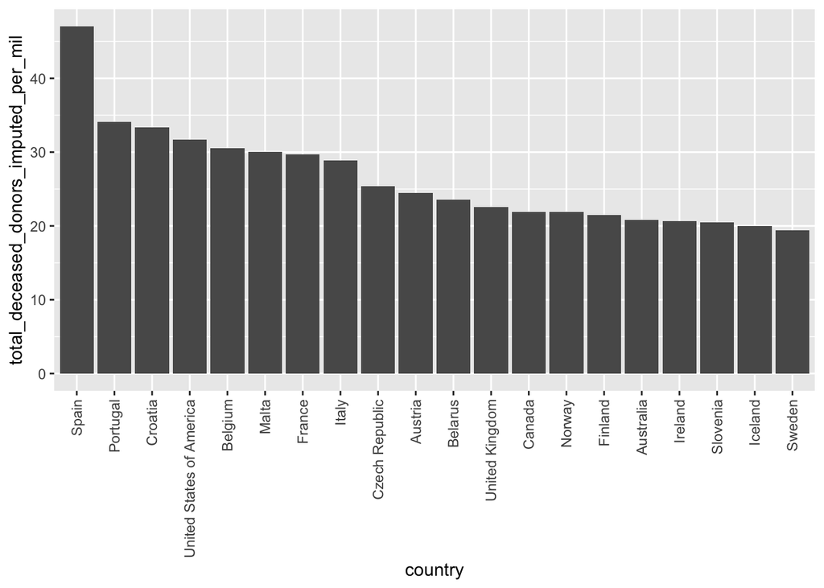

Figure 5: A bar chart showing the number of 2017 organ donations per million for the 20 countries with the highest number of donations per million

```r
organs_preprocessed |>
  # filter to the top 20 countries in 2017
  filter(year == 2017, country %in% countries_top_20_2017_per_mil$country) |>
  # arrange in descending order of donor count per mil
  arrange(desc(total_deceased_donors_imputed_per_mil)) |>
  # force the countries to appear in the order of donors per mil
  mutate(country = fct_inorder(country)) |>
  # create a bar plot
  ggplot() +
  geom_col(aes(x = country, y = total_deceased_donors_imputed_per_mil)) +
  theme(axis.text.x = element_text(angle = 90, vjust = 0.5, hjust = 1))
```

When viewed in the context of population size, it appears that *Spain* (not the US) is the clear world-leader in organ donation *Rates*. China and Brazil don’t even feature this time (because their number of organ donations are not actually that impressive when viewed in the context of the size of their population).

### 3.1 PCS evaluation

#### Predictability

A quick literature search revealed that it is a very well-known fact that Spain is the world leader in organ donations. While it seems that many of these reports are based on the same data as this dataset that we are using, the fact that this information seems so broadly reported feels like reasonable evidence of the predictability of this finding.

Another way that we can demonstrate the predictability of this finding is by showing that it occurs not just in 2017, but also for 2016. The figure below reproduces the two bar charts above, but using the 2016 data. The results are very similar (although the extent to which Spain’s rates are higher than Portugal and Croatia’s is less extreme).

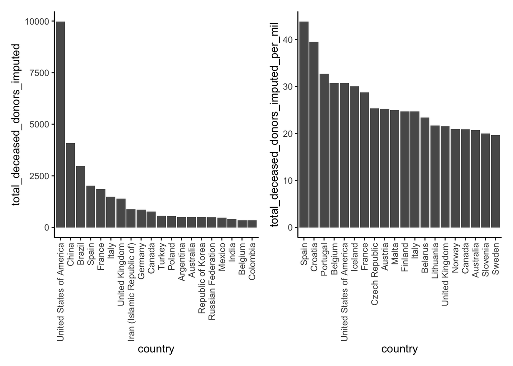

Figure 6: A bar chart showing the number of 2016 organ donations per million for the 20 countries with the highest number of donations per million

```r
countries_top_20_2016 <- organs_preprocessed |>
  filter(year == 2016) |>
  arrange(desc(total_deceased_donors_imputed)) |>
  head(20)
countries_top_20_2016_per_mil <- organs_preprocessed |>
  filter(year == 2016) |>
  arrange(desc(total_deceased_donors_imputed_per_mil)) |>
  head(20)

gg_donors_2016 <- organs_preprocessed |>
  filter(year == 2016, country %in% countries_top_20_2016$country) |>
  # force the countries to appear in the order of donors per mil
  arrange(desc(total_deceased_donors_imputed)) |>
  mutate(country = fct_inorder(country)) |>
  ggplot() +
  geom_col(aes(x = country, y = total_deceased_donors_imputed)) +
  theme_classic() +
  theme(axis.text.x = element_text(angle = 90, vjust = 0.5, hjust = 1))

gg_donors_2016_per_mil <- organs_preprocessed |>
  filter(year == 2016, country %in% countries_top_20_2016_per_mil$country) |>
  # force the countries to appear in the order of donors per mil
  arrange(desc(total_deceased_donors_imputed_per_mil)) |>
  mutate(country = fct_inorder(country)) |>
  ggplot() +
  geom_col(aes(x = country, y = total_deceased_donors_imputed_per_mil)) +
  theme_classic() +
  theme(axis.text.x = element_text(angle = 90, vjust = 0.5, hjust = 1))


gg_donors_2016 + gg_donors_2016_per_mil
```

#### Stability to a data visualization judgment call

Since this result is unlikely to change due to data perturbations and imputation judgment calls, let’s conduct a brief stability analysis evaluating whether our conclusions change if we use a different visualization technique to look at the data.

The figure below shows a heatmap of the organ donation rate for each country for each year (the rows are arranged in order of the 2017 rate). From this figure it is still very clear that Spain is a world leader in organ donations!

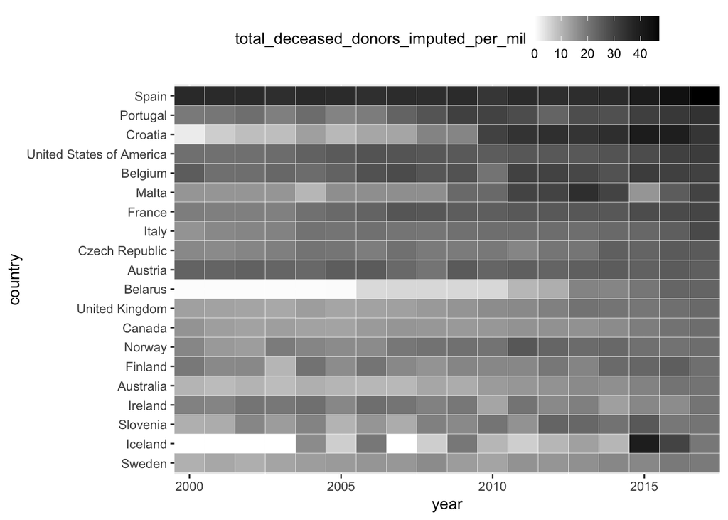

Figure 7: A heatmap of the donor rate for each country/year

```r
organs_preprocessed |>
  filter(country %in% countries_top_20_2017_per_mil$country) |>
  # force the countries to appear in the order of donors per mil
  arrange(desc(year), total_deceased_donors_imputed_per_mil) |>
  mutate(country = fct_inorder(country)) |>
  ggplot() +
  geom_tile(aes(x = year, y = country,
                fill = total_deceased_donors_imputed_per_mil),
            col = "white") +
  scale_fill_gradient(low = "white", high = "black") +
  scale_x_continuous(expand = c(0, 0)) +
  theme(legend.position = "top")
```

### 3.2 Creating an explanatory figure

Let’s turn this 2017 donor rates per million figure into a nice explanatory figure that we can use to show people Spain’s donor rate.

All we will do is clean up the plot by removing the background, tidying the axis names, and highlighting Spain.

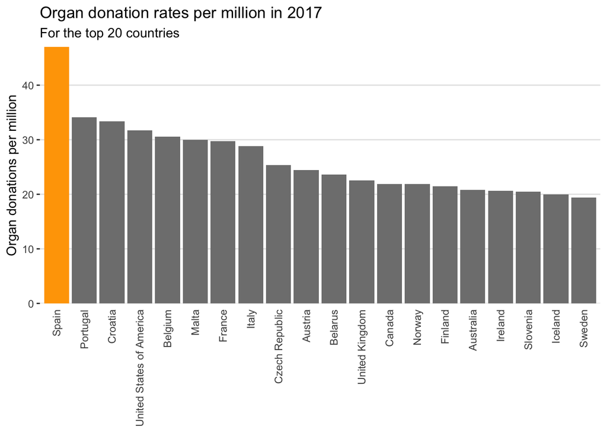

```r
organs_preprocessed |>
  # filter to the top 20 countries in 2017
  filter(year == 2017, country %in% countries_top_20_2017_per_mil$country) |>
  # arrange in descending order of donor count per mil
  arrange(desc(total_deceased_donors_imputed_per_mil)) |>
  # force the countries to appear in the order of donors per mil
  mutate(country = fct_inorder(country)) |>
  # create a bar plot
  ggplot() +
  geom_col(aes(x = country, y = total_deceased_donors_imputed_per_mil,
               fill = country == "Spain")) +
  scale_fill_manual(values = c("grey50", "Orange")) +
  theme_classic() +
  labs(x = NULL, y = "Organ donations per million",
       title = "Organ donation rates per million in 2017",
       subtitle = "For the top 20 countries") +
  scale_y_continuous(expand = c(0, 0)) +
  theme(axis.text.x = element_text(angle = 90, vjust = 0.5, hjust = 1),
        legend.position = "none",
        axis.line = element_blank(),
        axis.ticks.x = element_blank(),
        panel.grid.major.y = element_line(color = "grey90"))
```

## 4 Visualizing the donor rates over time for each country

The heatmap in Figure 7 that we produced in our stability analysis above gave us an idea that it might be interesting to visualize the donor rates over time using line plots.

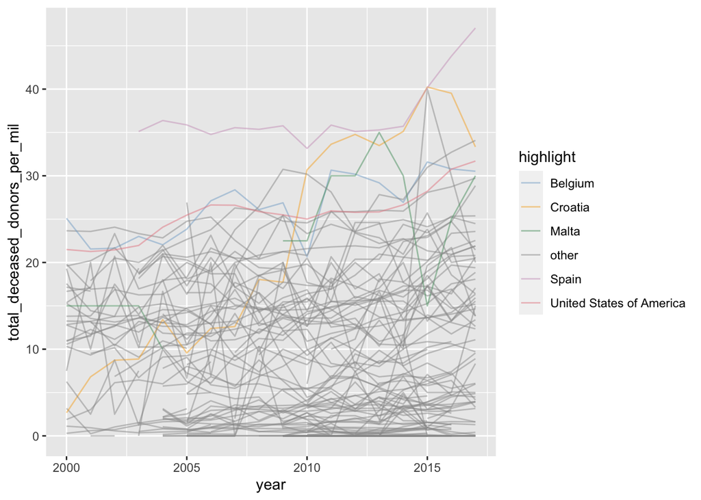

Figure 8: Trend lines for each country’s donor rates

```r
organs_preprocessed |>
  #dplyr::filter(year < 2013) |>
  mutate(highlight = if_else(country %in% c("Spain", "Croatia", "Belgium", "Malta", "United States of America"), as.character(country), "other")) |>
  ggplot() +
  geom_line(aes(x = year, y = total_deceased_donors_per_mil, col = highlight, group = country), alpha = 0.5) +
  scale_color_manual(values = c("#84ACCE", "#F6AE2D", "#589D6F", "grey60", "#CEA1C3", "#E68992"))
```

### 4.1 PCS evaluations

Since our conclusions from this figure is related to our results above, the PCS evaluations that we conducted above are also relevant to this Figure (e.g., we showed stability to a visualization judgment calls by the same information using a heatmap, and we showed predictability used domain literature to show that it is well-known that Spain is a world leader in organ donation rates). But we can also conduct a PCS analysis of these findings to some data perturbations and some additional visualization judgment calls (such as our choice of which countries lines to include in the plot).

#### Stability to data perturbations

Spain’s trend lines are highlighted in purple. Fortunately, even with 30% of the organ donor counts perturbed, Spain is consistently the world leader in deceased organ donations, indicating that this conclusion is fairly stable even to these fairly extreme data perturbations.

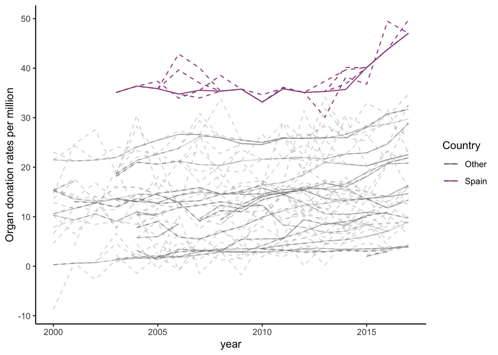

```r
set.seed(4395)
perturbed_organs_data <- organs_preprocessed |>
  # for each country, compute its standard deviation and record it in a column
  group_by(country) |>
  mutate(sd = sd(total_deceased_donors_imputed)) |>
  ungroup() |>
  # for each row in the data:
  rowwise() |>
  # compute four different perturbed versions of the total_deceased_donors variable
  # this involves adding a random Normal number to 30% of the values.
  # Note that we don't add noise to 0 counts.
  mutate(donors_pert1 = if_else((total_deceased_donors != 0) & (rbinom(1, 1, 0.3) == 1),
                                true = total_deceased_donors + rnorm(1, 0, sd),
                                false = total_deceased_donors),
         donors_pert2 = if_else((total_deceased_donors != 0) & (rbinom(1, 1, 0.3) == 1),
                                true = total_deceased_donors + rnorm(1, 0, sd),
                                false = total_deceased_donors),
         donors_pert3 = if_else((total_deceased_donors != 0) & (rbinom(1, 1, 0.3) == 1),
                                true = total_deceased_donors + rnorm(1, 0, sd),
                                false = total_deceased_donors),
         donors_pert4 = if_else((total_deceased_donors != 0) & (rbinom(1, 1, 0.3) == 1),
                                true = total_deceased_donors + rnorm(1, 0, sd),
                                false = total_deceased_donors)) |>
  # filter to countries with at least 500 total donors
  group_by(country) |>
  mutate(total_donors = max(total_deceased_donors_imputed)) |>
  ungroup() |>
  filter(total_donors > 500)

# plot the perturbed trendlines and the original trendline
perturbed_organs_data |>
  # add a column that identifies which rows correspond to Spain
  mutate(Spain = country == "Spain") |>
  ggplot() +
  # add the original donor trend lines for each country, and color Spain
  geom_line(aes(x = year, y = 1000000 * (total_deceased_donors / population),
                group = country, col = Spain, alpha = Spain)) +
  # add the first set of perturbed trend lines for each country, and color Spain
  geom_line(aes(x = year, y = 1000000 * (donors_pert1 / population),
                group = country, col = Spain, alpha = Spain),
            linetype = "dashed") +
  # add the second set of perturbed trend lines for each country, and color Spain
  geom_line(aes(x = year, y = 1000000 * (donors_pert2 / population),
                group = country, col = Spain, alpha = Spain),
            linetype = "dashed") +
  # add the third set of perturbed trend lines for each country, and color Spain
  geom_line(aes(x = year, y = 1000000 * (donors_pert3 / population),
                group = country, col = Spain, alpha = Spain),
            linetype = "dashed") +
  # add the fourth set of perturbed trend lines for each country, and color Spain
  geom_line(aes(x = year, y = 1000000 * (donors_pert4 / population),
                group = country, col = Spain, alpha = Spain),
            linetype = "dashed") +
  scale_color_manual("Country",
                     values = c("grey50", "#9C528B"),
                     labels = c("Other", "Spain")) +
  labs(y = "Organ donation rates per million") +
  scale_alpha_manual(values = c(0.3, 1), guide = "none") +
  theme_classic()
```

#### Stability to a data visualization judgment call

Next, let’s investigate whether our conclusion changes when we change which country’s lines are included in our figure. Our original figure filtered to the *top 20* countries in 2017. Alternative judgment calls that we could have made include not filtering the data at all (i.e., including all countries), filtering just to the countries that had at least one year with 500 reported donations, or filtering to the countries that had at least one year with a donor rate of at least 20 donors per million.

The analysis below re-creates the figure using each of these judgment calls.

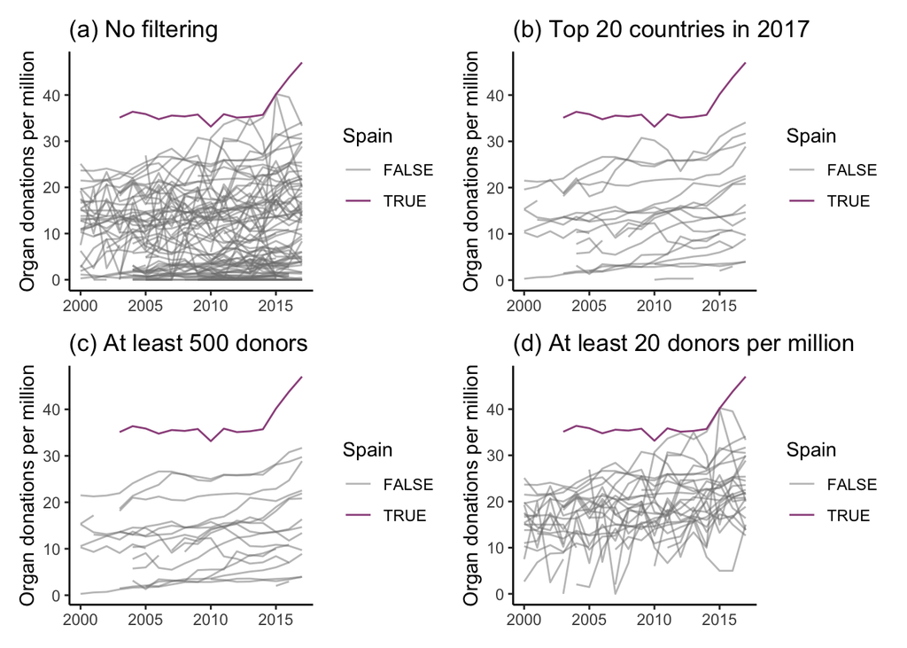

Figure 9: A series of multi-line plots displaying the organ donation rate per million over time based on four alternative filtering judgment calls (a) all countries, (b) the top 20 countries in 2017, (c) countries that reported at least 500 donors for at least one year, and (d) countries that reported at least 20 donors per million for at least one year.

```r
# create a function that we can re-use to create each plot
plotLines <- function(data) {
  gg <- data |>
    ggplot() +
    geom_line(aes(x = year, y = (total_deceased_donors / population) * 1000000,
                  col = Spain, alpha = Spain, group = country)) +
    theme_classic() +
    scale_color_manual(values = c("grey50", "#9C528B")) +
    scale_alpha_manual(values = c(0.5, 1)) +
    labs(y = "Organ donations per million",
         x = NULL)
  return(gg)
}



# No filtering
gg_no_filter <- organs_preprocessed |>
  # add a column that specifies whether the current row corresponds to Spain
  mutate(Spain = (country == "Spain")) |>
  plotLines() +
  ggtitle("(a) No filtering")


# filter to the 20 countries with the highest organ donation rates in 2017
gg_2017 <- organs_preprocessed |>
  filter(country %in% countries_top_20_2017$country) |>
  # add a column that specifies whether the current row corresponds to Spain
  mutate(Spain = (country == "Spain")) |>
  plotLines() +
  ggtitle("(b) Top 20 countries in 2017")


# Filter to countries with at least 500 donors
gg_500donors <- organs_preprocessed |>
  # add a column that specifies whether the current row corresponds to Spain
  mutate(Spain = (country == "Spain")) |>
  # compute the largest donor entry for each country and record it in a column
  group_by(country) |>
  mutate(total_donors = max(total_deceased_donors_imputed)) |>
  ungroup() |>
  # filter to the countries with at least 500 donors in at least one year
  filter(total_donors > 500) |>
  # create the figure
  plotLines() +
  ggtitle("(c) At least 500 donors")

# Filter to countries with at least 20 donors per million
gg_20donors_per_mil <- organs_preprocessed |>
  # add a column that specifies whether the current row corresponds to Spain
  mutate(Spain = (country == "Spain")) |>
  # identify the largest donor rate entry for each country and record it in a column
  group_by(country) |>
  mutate(total_donors_per_mil = max(total_deceased_donors_imputed / population_imputed) * 1000000) |>
  ungroup() |>
  # filter to countries with at least one donor rate entry above 20
  filter(total_donors_per_mil >= 20) |>
  plotLines() +
  ggtitle("(d) At least 20 donors per million")

# combine the plots using patchwork syntax
(gg_no_filter + gg_2017) / (gg_500donors + gg_20donors_per_mil)
```

### 4.2 Creating an explanatory figure

Let’s just look at the top 20 countries in 2017, and highlight Spain, Croatia, and the US. From here, you could try and re-create the plots for Spain and Croatia that we created in the book!

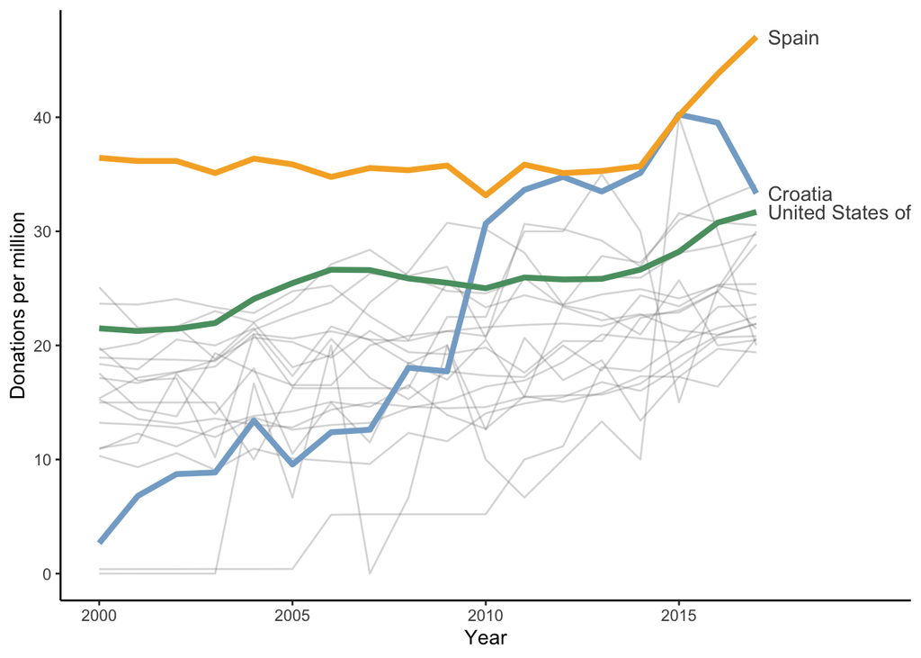

Figure 10: A cleaner line plot of (imputed) donor trends over time

```r
# create a temporary version of the organs clean dataset that just contains
# the top 20 countries in 2017 and adds a variable that contains the country
# name only for the countries of interest and "other" for all other countries
organs_preprocessed_top_20 <- organs_preprocessed |>
  filter(country %in% countries_top_20_2017_per_mil$country) |>
  mutate(highlight = if_else(country %in% c("Spain", "Croatia",
                                            "United States of America"),
                             as.character(country), "Other"))


organs_preprocessed_top_20 |>
  ggplot() +
  # add "Other" the line layers
  geom_line(aes(x = year, y = total_deceased_donors_imputed_per_mil,
                group = country),
            data = filter(organs_preprocessed_top_20, highlight == "Other"),
            alpha = 0.3, color = "grey50", linewidth = 0.5) +
  # add the Spain, Croatia, and US line layers
  geom_line(aes(x = year, y = total_deceased_donors_imputed_per_mil,
                group = country,
                col = highlight),
            data = filter(organs_preprocessed_top_20, highlight != "Other"), linewidth = 1.5) +
  # add the country name annotation
  geom_text(aes(x = year, y = total_deceased_donors_imputed_per_mil,
                label = country),
            data = filter(organs_preprocessed_top_20,
                          highlight != "Other", year == 2017),
            hjust = 0, nudge_x = 0.3, col = "grey30") +
  # Choose the colors
  scale_color_manual("Country", values = c("#84ACCE", "#F6AE2D", "#589D6F"), guide = NULL) +
  scale_x_continuous(limits = c(2000, 2020), breaks = seq(2000, 2015, 5)) +
  # remove grid
  theme_classic() +
  labs(x = "Year", y = "Donations per million")
```

Another way to present this data is using a grid of line plots.

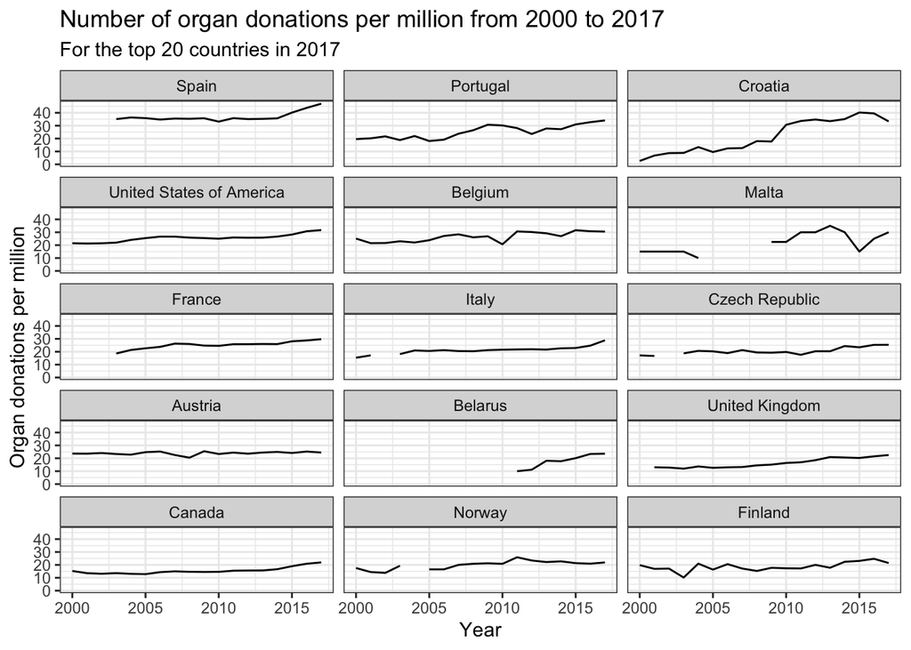

Figure 11: This plot shows a grid of the unimputed donation counts per million over time for each of the top 15 countries in 2017

```r
organs_preprocessed |>
  # filter to the top 15 countries in 2017
  filter(country %in% countries_top_20_2017_per_mil$country[1:15]) |>
  # make sure that the countries are arranged in 2017 donor rate order
  arrange(desc(year), desc(total_deceased_donors_imputed_per_mil)) |>
  mutate(country = fct_inorder(country)) |>
  # create line plots
  ggplot() +
  geom_line(aes(x = year, y = total_deceased_donors_per_mil)) +
  # split line plots by country
  facet_wrap(~country, ncol = 3) +
  # Clean up the the plot
  scale_y_continuous("Organ donations per million") +
  scale_x_continuous("Year",
                     breaks = seq(2000, 2017, 5)) +
  theme_bw() +
  theme(legend.position = "none",
        axis.line = element_blank()) +
  ggtitle("Number of organ donations per million from 2000 to 2017",
          subtitle = "For the top 20 countries in 2017")
```

## 5 The relationship between population and number of donors

Having observed that the donor rate paints a different picture from the raw number of donors, we assumed that countries with larger populations have more donors. Let’s check this assumption by asking *do countries with larger populations typically have more donors?*

```r
cor_pop_donor <- organs_preprocessed |>
  filter(year == 2017) |>
  summarise(cor = cor(population_imputed, total_deceased_donors_imputed)) |>
  pull(cor)
cor_pop_donor
```

```
[1] 0.4128076
```

The correlation between the (imputed) population and number of donors is 0.41, which is indicative of a possible weak linear relationship.

Looking at a scatterplot of the two variables does not provide too many hints about this supposed weak linear relationship, however, due to the concentration of values in the lower-left corner.

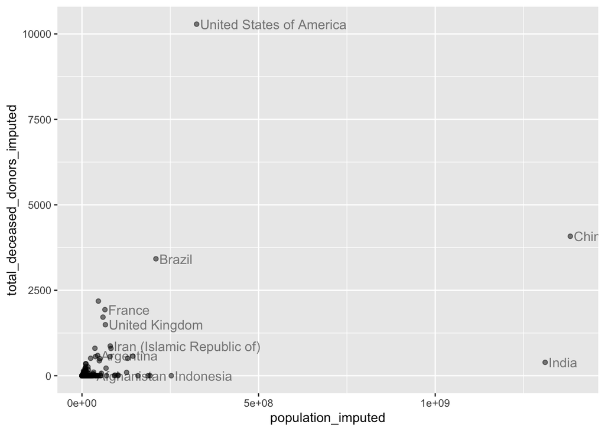

```r
organs_preprocessed |>
  filter(year == 2017) |>
  ggplot() +
  geom_point(aes(x = population_imputed, y = total_deceased_donors_imputed),
             alpha = 0.5) +
  geom_text(aes(x = population_imputed, y = total_deceased_donors_imputed,
                label = country),
             alpha = 0.5, check_overlap = TRUE, hjust = 0, nudge_x = 10000000)
```

Removing the outlier countries makes it a little easier to see some trends:

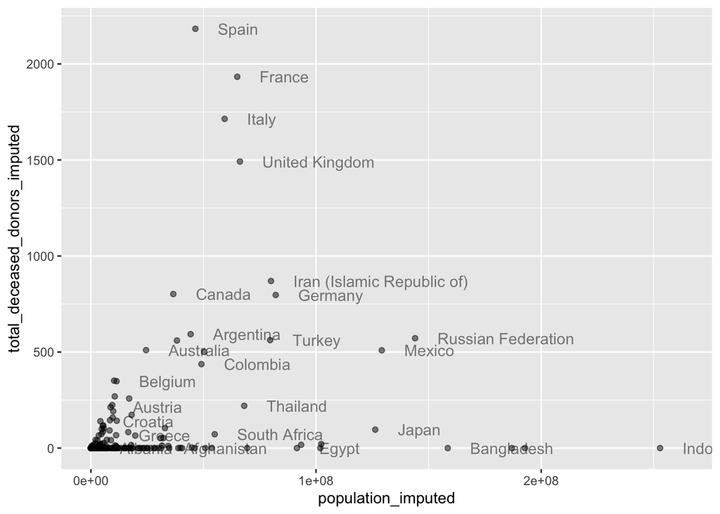

```r
organs_preprocessed |>
  filter(year == 2017, total_deceased_donors_imputed < 2500, population_imputed < 500000000) |>
  ggplot() +
  geom_point(aes(x = population_imputed, y = total_deceased_donors_imputed),
             alpha = 0.5) +
  geom_text(aes(x = population_imputed, y = total_deceased_donors_imputed,
                label = country),
             alpha = 0.5, check_overlap = TRUE, hjust = 0, nudge_x = 10000000)
```

But taking a log-log transformation of the plot shows that, *if we ignore the countries with zero donations*, there is a reasonable linear relationship between the log of population and the log of donor count (indicating that a percentage increase in population is associated with a percentage increase in donor count). However, by ignoring these countries we risk presenting a severely biased view of the data.

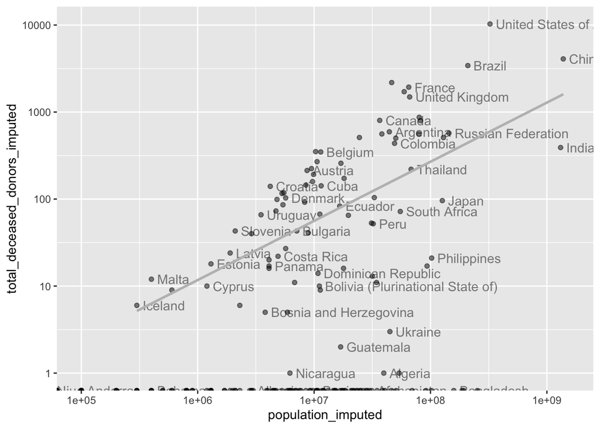

```r
organs_preprocessed |>
  filter(year == 2017) |>
  ggplot() +
  geom_point(aes(x = population_imputed, y = total_deceased_donors_imputed),
             alpha = 0.5) +
  geom_text(aes(x = population_imputed, y = total_deceased_donors_imputed,
                label = country),
             alpha = 0.5, check_overlap = TRUE, hjust = 0, nudge_x = 0.05) +
  geom_smooth(aes(x = population_imputed, y = total_deceased_donors_imputed),
              method = "lm", se = FALSE, col = "grey") +
  scale_x_log10() +
  scale_y_log10()
```

This finding doesn’t feel particularly informative, so we won’t turn it into an explanatory finding, nor will we conduct a thorough PCS evaluation of it.

## 6 [Exercise: to complete] Is there a difference in deceased donor type (i.e., whether the organs come from brain death or circulatory death donors) across different countries?

Conduct your own analysis to answer this question. The relevant variables in the pre-processed data (`organs_preprocessed`) will be `deceased_donors_brain_death`, `deceased_donors_circulatory_death`, and `country`.

## 7 [Exercise: to complete] Create a dot plot copmaring the organ donation rates for the US and Spain

Below you will find some code for creating the data that underlies the dot plot in Exercise 27 of Chapter 6. Use `geom_line()` and `geom_point()` to create the dot plot.

```r
organs_preprocessed %>%
  filter(country %in% c("Spain", "United States of America"),
         year == 2017) %>%
  transmute(country,
            kidney = total_kidney_tx / population * 1000000,
            liver = total_liver_tx / population * 1000000,
            heart = total_heart_tx / population * 1000000,
            lung = total_lung_tx / population * 1000000) %>%
  pivot_longer(c("kidney", "liver", "heart", "lung"),
               names_to = "organ", values_to = "donation_rate") %>%
  arrange(donation_rate) %>%
  mutate(organ = fct_inorder(organ))
```

| country | organ | donation_rate |
| --- | --- | --- |
| Spain | heart | 6.551724 |
| United States of America | lung | 7.636364 |
| Spain | lung | 7.823276 |
| United States of America | heart | 10.086287 |
| United States of America | liver | 24.906009 |
| Spain | liver | 26.875000 |
| United States of America | kidney | 63.599384 |
| Spain | kidney | 70.452586 |

## 8 Additional explorations

There are many more explorations that you could include in this document if you are editing it yourself (we’ve only included the ones that appeared in the EDA book chapter), and if you’re interested in challenging yourself we encourage you to add a few additional exploration sections to this document.

Start by thinking of a question you have about a data trend or relationship. Perhaps it is related to some of the organ-specific transplant variables that we haven’t explored, or perhaps you even want to bring in some external data (such as GDP) to explore whether there is a relationship between GDP and organ donation rates. There are almost infinite avenues that you can explore!